# Proteom change vs TSB control after 15mi pulse and 15h SN

Bio253 HS2026 · group: 15min (names: simona_michelle)

Copy this file (e.g. `07_groupX_my_question.qmd`) and fill in every section. Keep it short and honest. A clear negative result is a good result.

```r
source("../R/setup.R")
```

## 1. Question

*Does the* S. aureus* JE2 proteome (wild type, anc) change only little after 15 min of *P. aeruginosa* supernatant exposure, compared to the long-term (~15 h) exposure? (Protein part of Topic 1; the phospho part is analysed separately.) Looking at a change in protein abundance: how much of each protein the cells contain after supernatant exposure, compared with the TSB control. There are two levels to it.*

## 2. Hypothesis

- **H1:**After 15 min (SNpulse) only a small fraction of proteins changes, clearly less than after ~15 h (SN).
- **H0:**The fraction of changed proteins after 15 min is not smaller than after ~15 h.
- **Prediction:** which contrast / sites / proteins, which sign of `diff`, which minimal effect size would you call relevant? (Write this *before* looking.)
  - Contrasts: `TSB_vs_SNpulse_at_anc` vs. `TSB_vs_SN_at_anc` (`diff < 0` = higher in PASN)
  - “Changed”: |log2FC| > 1 and FDR < 0.05
  - “Reliably measured”: ≥ 2 of 3 replicates in both compared groups
  - Expected: only a few % after 15 min, clearly more after ~15 h

```r
# Check the direction of the contrast you will use, e.g.
explain_contrast("TSB_vs_SN_at_anc")
```

```
[1] "TSB_vs_SN_at_anc: diff = log2(TSB) - log2(SN), within anc. diff > 0 means HIGHER in TSB; diff < 0 means HIGHER in SN."
```

## 3. Data used

*Which tables (total proteome / phospho STY / STYH / site tables), which samples, which filters (e.g. contaminants removed, ≥ 2/3 replicates)?* * **Table:** total proteome, differential expression results (`dea_total`) and per-sample normalised abundances (`abundances_total`, log2, vsn-normalised) * **Samples:** wild type JE2 (anc) only: TSB (control), SNpulse (15 min PASN), SN (~15 h PASN); n = 3 per group * **Contrasts:** `TSB_vs_SNpulse_at_anc`, `TSB_vs_SN_at_anc` * **Filters:** * contaminants removed (default of `read_dea()` / `read_abundances()`) * “reliably measured”: detected (not NA) in ≥ 2 of 3 replicates in both compared groups **and** DEA estimate based on observed values (`estimate_type == "observed"`, no imputation) * Note: the `observed` criterion was added after the first analysis, to use exactly the same rule as the phospho analysis (Michelle). It changed the numbers only slightly (15 min: 37/2105 → 35/2003 changed proteins).

```r
contr <- c("TSB_vs_SNpulse_at_anc", "TSB_vs_SN_at_anc")

dea <- read_dea("total", contrasts = contr)
ab  <- read_abundances("total")
# read_dea("total", contrasts = contr) reads dea_total.tsv.gz, removes contaminants (proteins the mass spectrometer detects that don’t come from your biological sample) and keeps only your two contrasts
# read_abundances("total") reads the normalised values for every sample.

# Number of detected replicates (of 3) per protein and medium, wild type only
# Count detections. For the wild type only (anc), you count for each protein and medium how many of the 3 replicates have a value (not NA). The result is one row per protein, with columns TSB, SNpulse and SN, each holding a number from 0 to 3.
n_obs <- ab |>
  filter(genotype == "anc") |>
  group_by(protein_key, medium) |>
  summarise(n = sum(!is.na(normalized_abundance)), .groups = "drop") |>
  pivot_wider(names_from = medium, values_from = n, values_fill = 0)

# Add reliability flag and "changed" flag
# Reliable means detected in at least 2 of 3 replicates in both groups being compared
# AND the DEA estimate is based on observed values (estimate_type == "observed", not imputed).
# Same rule as in the phospho analysis, so proteins and phosphosites are comparable.
# Changed means FDR < 0.05 and |log2FC| > 1. That FDR is stricter than the course default of 0.1, so mention it in your Methods section.
dea <- dea |>
  left_join(n_obs, by = "protein_key") |>
  mutate(reliable = case_when(
           contrast == "TSB_vs_SNpulse_at_anc" ~ TSB >= 2 & SNpulse >= 2,
           contrast == "TSB_vs_SN_at_anc"      ~ TSB >= 2 & SN >= 2),
         reliable = reliable & estimate_type == "observed",
         changed = FDR < 0.05 & abs(diff) > 1)

# Quick overview: how many proteins per contrast, how many reliable?
dea |> count(contrast, reliable)
```

| contrast | reliable | n |
| --- | --- | --- |
| TSB_vs_SN_at_anc | FALSE | 321 |
| TSB_vs_SN_at_anc | TRUE | 1979 |
| TSB_vs_SNpulse_at_anc | FALSE | 297 |
| TSB_vs_SNpulse_at_anc | TRUE | 2003 |

```r
# Count. count(contrast, reliable) counts how many proteins are reliable or not in each contrast. That’s the table you see.
```

## 4. Methods

*What did you compute and why? Which R functions / packages? If an AI agent wrote code for you: what did you check yourself? I wrote my code with the help of claude, i already added comments to my code, what exactly was done*

## 5. Results

Always start with the raw per-sample values:

The raw values are the individual measurements for each sample, before any statistics. They come from your ab table (abundances_total.tsv.gz), column normalized_abundance.

What the plot shows: For each of your top proteins you get one small panel: - x-axis: the three media, TSB, SNpulse and SN. - Points: the 3 replicates per medium, one point per sample. - Box: the spread of those 3 values. - “3/3”, “2/3” etc. on top: how many replicates actually have a value.

log2 scale: a difference of 1 means 2× more, 2 means 4× more, and so on. vsn-normalised: the samples were adjusted so that they’re comparable to each other, for example if slightly more material was loaded in one tube. NA: the protein wasn’t detected in that sample. That doesn’t mean zero; it may just have been below the detection limit.

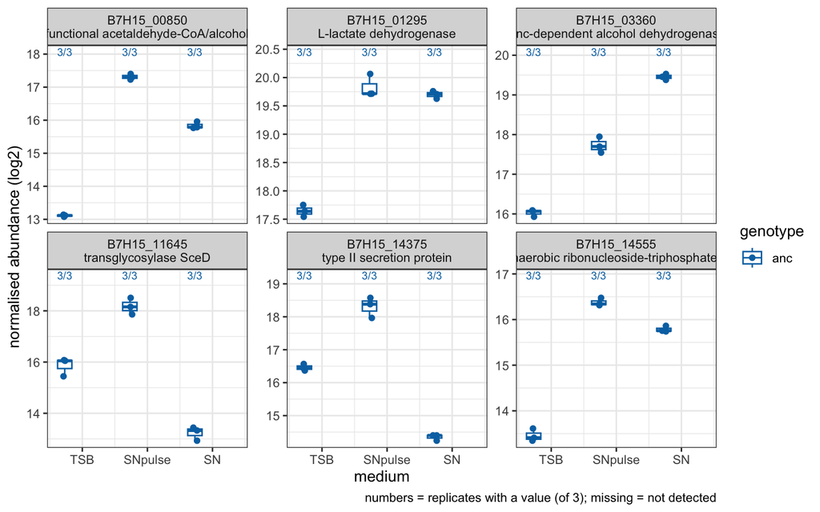

```r
# Top 6 changed proteins after 15 min (smallest FDR)
top_pulse <- dea |>
  filter(contrast == "TSB_vs_SNpulse_at_anc", reliable, changed) |>
  arrange(FDR) |>
  slice_head(n = 6) |>
  pull(protein_key)

ab_anc <- filter(ab, genotype == "anc")

if (length(top_pulse) > 0) plot_protein(top_pulse, ab_anc)
```

```r
dea |>
  filter(protein_key %in% top_pulse) |>
  select(protein_key, contrast, diff, FDR, estimate_type) |>
  mutate(fold_change = 2^abs(diff),
         direction   = if_else(diff < 0, "up in PASN", "down in PASN")) |>
  arrange(protein_key, contrast)
```

| protein_key | contrast | diff | FDR | estimate_type | fold_change | direction |
| --- | --- | --- | --- | --- | --- | --- |
| lcl_CP020619.1_prot_ARG44688.1_168 | TSB_vs_SN_at_anc | -2.722327 | 0.0e+00 | observed | 6.599364 | up in PASN |
| lcl_CP020619.1_prot_ARG44688.1_168 | TSB_vs_SNpulse_at_anc | -4.188988 | 0.0e+00 | observed | 18.239417 | up in PASN |
| lcl_CP020619.1_prot_ARG44770.1_257 | TSB_vs_SN_at_anc | -2.048292 | 0.0e+00 | observed | 4.136159 | up in PASN |
| lcl_CP020619.1_prot_ARG44770.1_257 | TSB_vs_SNpulse_at_anc | -2.187024 | 0.0e+00 | observed | 4.553653 | up in PASN |
| lcl_CP020619.1_prot_ARG45139.1_649 | TSB_vs_SN_at_anc | -3.426611 | 0.0e+00 | observed | 10.752580 | up in PASN |
| lcl_CP020619.1_prot_ARG45139.1_649 | TSB_vs_SNpulse_at_anc | -1.700713 | 0.0e+00 | observed | 3.250616 | up in PASN |
| lcl_CP020619.1_prot_ARG46658.1_2256 | TSB_vs_SN_at_anc | 2.585875 | 1.3e-06 | observed | 6.003794 | down in PASN |
| lcl_CP020619.1_prot_ARG46658.1_2256 | TSB_vs_SNpulse_at_anc | -2.290177 | 1.0e-07 | observed | 4.891160 | up in PASN |
| lcl_CP020619.1_prot_ARG47157.1_2793 | TSB_vs_SN_at_anc | 2.117836 | 0.0e+00 | observed | 4.340423 | down in PASN |
| lcl_CP020619.1_prot_ARG47157.1_2793 | TSB_vs_SNpulse_at_anc | -1.838389 | 0.0e+00 | observed | 3.576104 | up in PASN |
| lcl_CP020619.1_prot_ARG47192.1_2829 | TSB_vs_SN_at_anc | -2.354177 | 0.0e+00 | observed | 5.113024 | up in PASN |
| lcl_CP020619.1_prot_ARG47192.1_2829 | TSB_vs_SNpulse_at_anc | -2.946110 | 0.0e+00 | observed | 7.706685 | up in PASN |

There’s a clear biological pattern

Four of the six proteins belong to fermentation and anaerobic metabolism: making lactate and ethanol, and a DNA-building enzyme that only works without oxygen. This looks like S. aureus switching from respiration to fermentation. That fits what’s known: P. aeruginosa secretes molecules such as HQNO and cyanide that block S. aureus respiration. It’s worth checking whether the papers in your project describe this, especially Niggli et al.

How to read it

Sign: diff = log2(TSB) − log2(PASN). A negative value means more protein after supernatant exposure, and a positive value means less. Size: it’s on a log2 scale, so 1 = 2×, 2 = 4×, 3 = 8×. To turn it into a normal fold change, compute 2^|diff|.

```r
# 1. Fraction of changed proteins per contrast (reliable proteins only)
frac <- dea |>
  filter(reliable) |>
  group_by(contrast) |>
  summarise(n_reliable = n(),
            n_changed  = sum(changed),
            fraction   = n_changed / n_reliable)
frac
```

| contrast | n_reliable | n_changed | fraction |
| --- | --- | --- | --- |
| TSB_vs_SN_at_anc | 1979 | 375 | 0.1894896 |
| TSB_vs_SNpulse_at_anc | 2003 | 35 | 0.0174738 |

```r
# 2. Up vs down (diff < 0 = higher after PASN)
dea |>
  filter(reliable, changed) |>
  mutate(direction = if_else(diff < 0, "up in PASN", "down in PASN")) |>
  count(contrast, direction)
```

| contrast | direction | n |
| --- | --- | --- |
| TSB_vs_SN_at_anc | down in PASN | 240 |
| TSB_vs_SN_at_anc | up in PASN | 135 |
| TSB_vs_SNpulse_at_anc | down in PASN | 8 |
| TSB_vs_SNpulse_at_anc | up in PASN | 27 |

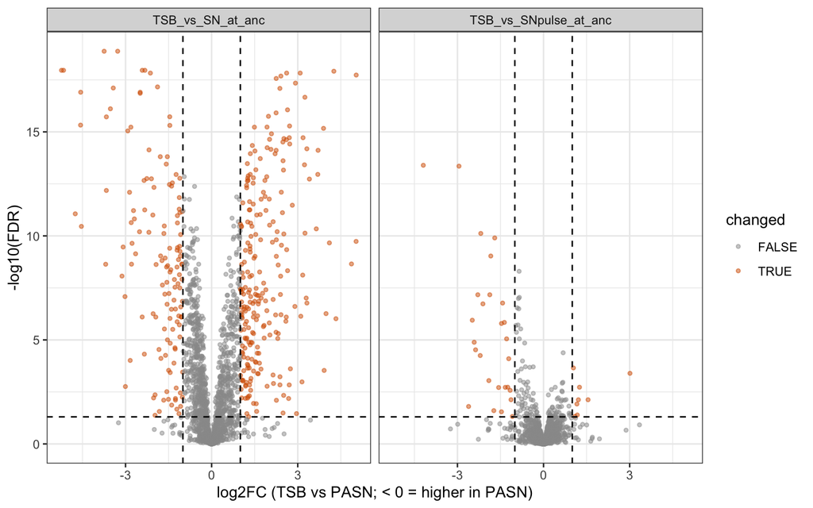

```r
# 3. Volcano plots
dea |>
  filter(reliable) |>
  ggplot(aes(x = diff, y = -log10(FDR), colour = changed)) +
  geom_point(alpha = 0.5, size = 1) +
  geom_vline(xintercept = c(-1, 1), linetype = "dashed") +
  geom_hline(yintercept = -log10(0.05), linetype = "dashed") +
  facet_wrap(~ contrast) +
  scale_colour_manual(values = c(`FALSE` = "grey60", `TRUE` = "#D55E00")) +
  labs(x = "log2FC (TSB vs PASN; < 0 = higher in PASN)", y = "-log10(FDR)")
```

After 15 min, only 35 of 2003 reliably measured proteins (1.7 %) change by at least 2× with FDR < 0.05. After ~15 h, it’s 375 of 1979 proteins (18.9 %), about 10× more.

That’s exactly what you predicted: only a few % at 15 min, clearly more at 15 h.

15 min: mostly increases. About three quarters of the early changes go up. That fits your top 6 and the idea of a fast, targeted switch-on, e.g. fermentation enzymes. It also makes sense mechanically: a cell can raise a protein quickly by making more of it, but halving a protein within 15 min requires active degradation, which is slower and rarer. The 8 early decreases are worth a quick look in the raw-values plots, since a 2× drop in 15 min is unusual. ~15 h: mostly decreases. Long-term, more proteins go down than up. A plausible reason is that the SN medium is 30 % spent P. aeruginosa medium and partly nutrient-depleted, so after many hours the cells have reorganised their whole metabolism and turned down many pathways. Over many generations, proteins that are no longer made are also diluted out by growth.

Volcano plot: The axes x-axis: log2 fold change (diff). This shows how strongly a protein changes. 0 means no change. Because of the contrast direction, left (negative) = higher after PASN and right (positive) = lower after PASN. Each step of 1 is a doubling: −3 means 8× higher in PASN. y-axis: −log10(FDR). This shows how statistically certain the change is. The minus-log flips small FDRs into big numbers, so higher = more certain. 1.3 corresponds to FDR = 0.05, 2 to 0.01, and 10 to 10⁻¹⁰.

The lines and colours Vertical dashed lines at −1 and +1: your 2× effect-size threshold. Horizontal dashed line at 1.3: your FDR = 0.05 threshold. Orange points: proteins that pass both thresholds, i.e. your “changed” ones, in the upper left and upper right corners. Grey points don’t.

## 6. Caveats

*Missing values / imputation? Only 3 replicates? Multiple testing? Is the `stp` strain a clean mutant (notebook 03)? Protein abundance vs activity? Batch effects (re-injected samples)?*

1. 15 min vs ~15 h is not only a difference in time. SN cells were grown for ~15 h in a different medium (70 % TSB + 30 % PASN, partly nutrient-depleted), while SNpulse cells were grown in TSB and only exposed for 15 min. Part of the larger change at 15 h may therefore reflect growth in a poorer medium and a different growth state, not only longer PASN exposure.
2. Only 3 replicates per group. Small effects or variable proteins may be missed, and FDR values from n = 3 are sensitive to single outlying samples. The top hits looked consistent in the raw values (3/3 replicates, tight spread), but this was not checked for all 35 + 375 proteins.
3. Thresholds determine the counts. The fractions depend on the chosen cut-offs (FDR < 0.05, |log2FC| > 1). The volcano plots show many proteins, especially at 15 h, that are significant but change less than 2-fold. With the course default (FDR < 0.1) or a lower fold-change cut-off the absolute numbers would change; the large difference between 15 min and 15 h makes it unlikely that the main conclusion would change.
4. Missing values and imputation. Proteins detected in < 2 of 3 replicates or with an imputed DEA estimate were excluded. This removes fold changes based on imputed values, but it also excludes on/off proteins (e.g. detected in TSB but absent in SN). The number of excluded proteins was higher at 15 h (321) than at 15 min (297), so the fraction of changed proteins at 15 h is, if anything, underestimated.

## 7. Conclusion and next steps

*Answer your question in 2–3 sentences. What experiment or analysis would you do next?*

We hypothesised that after 15 min of PASN exposure only a small fraction of the S. aureus JE2 proteome changes, clearly less than after ~15 h (H1), against the null hypothesis that the fraction after 15 min is not smaller (H0). Our data support H1: after 15 min, only 1.7 % of reliably measured proteins (35/2003) changed significantly (FDR < 0.05, |log2FC| > 1), compared with 18.9 % (375/1979) after ~15 h, about ten times more. The early response was nevertheless not random: it consisted mostly of increases (27 up, 8 down), including strong induction of fermentation enzymes (e.g. AdhE ≈ 18×, L-lactate dehydrogenase ≈ 4.6×), consistent with a rapid switch from respiration to fermentation, as expected if PASN components such as HQNO or cyanide inhibit respiration.

## 8. Sources

*Papers, databases (UniProt IDs, STRING), and AI tools used – with what for.*

Papers

Niggli et al., mBio (2023), doi:10.1128/mbio.03153-22. Background on P. aeruginosa supernatant inhibiting S. aureus (incl. JE2); HQNO inhibits the S. aureus respiratory chain (used for interpretation in section 7). Schwyter et al., mSystems (2025), doi:10.1128/msystems.00262-25. Proteome response of S. aureus JE2 to P. aeruginosa supernatant (context for the ~15 h response).

Databases

UniProt, S. aureus NCTC 8325 (STAA8) entries for the top hits: AdhE Q2G1K9 (B7H15_00850), L-lactate dehydrogenase LDH1 Q2G218 (B7H15_01295), zinc-dependent alcohol dehydrogenase ADH Q2G0G1 (B7H15_03360), transglycosylase SceD Q2FWF8 (B7H15_11645), type II secretion protein Q2FV34 (B7H15_14375), anaerobic ribonucleoside-triphosphate reductase Q2FV02 (B7H15_14555). Protein annotation and DEA results from the course data (prolfquapp; JE2 genome CP020619.1).

Software

R, tidyverse, Quarto, and the course repository bio253-je2-proteomics (helper functions read_dea(), read_abundances(), plot_protein()). Exact versions: see sessionInfo() below.

AI tools

Claude (Anthropic): explained the data structure, contrast direction and plot interpretation; drafted R code (fractions, up/down counts, volcano plots, top-hit table) and text drafts for sections 4–7. I ran all code myself, checked the contrast direction with explain_contrast(), compared the results with the raw-value plots, and revised the text.

[session information not shown]